# Value at Risk (VaR) — Parametric (Normal) Method (Clean Notebook)

This notebook computes **Value at Risk (VaR)** using the **Parametric (Normal)** approach.

## What you will do

- Choose a stock ticker (e.g., `AAPL`, `MSFT`, `NVDA`).
- Download daily adjusted close prices.
- Compute daily **simple returns**.
- Estimate **Parametric VaR** assuming returns are Normally distributed:
  - **Daily VaR**
  - **Horizon VaR** (e.g., 30‑day) using the Normal i.i.d. scaling rule

## Key idea (Parametric Normal VaR)

If daily returns are modeled as: [ R \sim \mathcal{N}(\mu, \sigma^2), ] then the ((1-c)) left‑tail quantile is: [ q_{1-c} = \mu + \sigma, z_{1-c}, ] where (z_{1-c}) is the standard Normal quantile (e.g., (z_{0.05}\approx -1.645)).

> **Convention used here:** VaR is reported as a **negative return** (loss threshold). Dollar VaR is therefore typically negative as well.

```python
# =========================
# 0) Imports
# =========================
import numpy as np
import pandas as pd
import yfinance as yf
import matplotlib.pyplot as plt
from scipy.stats import norm

pd.set_option("display.width", 140)
pd.set_option("display.max_columns", 60)
```

## 1) Inputs

- **TICKER**: stock symbol
- **START, END**: sample window
- **CONF_LEVELS**: VaR confidence levels
- **INITIAL_INV**: portfolio value (for dollar VaR)
- **HORIZON_DAYS**: multi‑day VaR horizon (computed using Normal i.i.d. scaling)

> Keep inputs consistent across Historical / Parametric / Monte Carlo notebooks so results are comparable.

```python
# =========================
# 1) User inputs (edit these)
# =========================
TICKER = "NVDA"
START = "2021-01-01"
END   = "2025-12-31"

CONF_LEVELS = [0.95, 0.99]   # 95% and 99% VaR
INITIAL_INV = 100000         # portfolio value ($)
HORIZON_DAYS = 30            # horizon VaR in trading days

TICKER, START, END, CONF_LEVELS, INITIAL_INV, HORIZON_DAYS
```

```
('NVDA', '2021-01-01', '2025-12-31', [0.95, 0.99], 100000, 30)
```

## 2) Download data and compute returns

We download **Adjusted Close** prices and compute:

- **Simple return**: (R_t = \frac{P_t - P_{t-1}}{P_{t-1}})

For consistency with the Historical notebook, we use **simple returns** here as well.

```python
# =========================
# 2) Download price data
# =========================
raw = yf.download(TICKER, start=START, end=END, progress=False, auto_adjust=False)

if raw.empty:
    raise ValueError(f"No data returned for ticker {TICKER}. Check the symbol and dates.")

df = raw[["Adj Close"]].rename(columns={"Adj Close": "adj_close"}).copy()
df["simple_rtn"] = df["adj_close"].pct_change()
df = df.dropna()

df.head()
```

| Price Ticker Date | adj_close NVDA | simple_rtn |
| --- | --- | --- |
| 2021-01-05 | 13.335952 | 0.022210 |
| 2021-01-06 | 12.549758 | -0.058953 |
| 2021-01-07 | 13.275515 | 0.057830 |
| 2021-01-08 | 13.208608 | -0.005040 |
| 2021-01-11 | 13.551589 | 0.025967 |

## 3) Estimate Normal parameters ((\mu), (\sigma))

Parametric VaR depends on the mean and volatility of returns. We estimate:

- (\hat\mu) = sample mean of daily returns
- (\hat\sigma) = sample standard deviation of daily returns

```python
# =========================
# 3) Parameter estimates
# =========================
mu_hat = df["simple_rtn"].mean()
sigma_hat = df["simple_rtn"].std(ddof=1)

pd.DataFrame({
    "Parameter": ["mu_hat (daily mean)", "sigma_hat (daily std dev)"],
    "Value": [mu_hat, sigma_hat]
})
```

|  | Parameter | Value |
| --- | --- | --- |
| 0 | mu_hat (daily mean) | 0.002663 |
| 1 | sigma_hat (daily std dev) | 0.032911 |

## 4) Parametric VaR — Daily

For confidence level (c), let (\alpha=1-c). The Normal left‑tail quantile is: [ \text{VaR}*{c,1} = \mu + \sigma, z*{\alpha}. ]

We also compute **Dollar VaR** for a portfolio value.

```python
# =========================
# 4) Parametric VaR (Daily)
# =========================
results_daily = []

for c in CONF_LEVELS:
    alpha = 1 - c
    z = norm.ppf(alpha)  # e.g., ppf(0.05) ~ -1.645
    var_r = mu_hat + sigma_hat * z
    var_usd = INITIAL_INV * var_r

    results_daily.append({
        "Confidence": f"{int(c*100)}%",
        "Daily VaR (return)": var_r,
        "Daily VaR ($)": var_usd,
        "z_(1-c)": z
    })

daily_table = pd.DataFrame(results_daily)
daily_table
```

|  | Confidence | Daily VaR (return) | Daily VaR ($) | z_(1-c) |
| --- | --- | --- | --- | --- |
| 0 | 95% | -0.051470 | -5147.012434 | -1.644854 |
| 1 | 99% | -0.073899 | -7389.862352 | -2.326348 |

## 5) Parametric VaR — Horizon (Normal i.i.d. scaling)

Under the i.i.d. Normal model, the (H)-day return is approximately Normal with:

- Mean: (\mu_H = H\mu)
- Std dev: (\sigma_H = \sqrt{H}\sigma)

So: [ \text{VaR}*{c,H} = \mu_H + \sigma_H, z*{\alpha}. ]

> This **(\sqrt{H})** scaling is a **parametric** assumption and differs from the rolling-compounding approach used for Historical VaR.

```python
# =========================
# 5) Parametric VaR (Horizon)
# =========================
H = HORIZON_DAYS
mu_H = H * mu_hat
sigma_H = np.sqrt(H) * sigma_hat

results_h = []
for c in CONF_LEVELS:
    alpha = 1 - c
    z = norm.ppf(alpha)
    var_h = mu_H + sigma_H * z
    var_h_usd = INITIAL_INV * var_h

    results_h.append({
        "Confidence": f"{int(c*100)}%",
        f"{H}-day VaR (return)": var_h,
        f"{H}-day VaR ($)": var_h_usd,
        "z_(1-c)": z
    })

horizon_table = pd.DataFrame(results_h)
horizon_table
```

|  | Confidence | 30-day VaR (return) | 30-day VaR ($) | z_(1-c) |
| --- | --- | --- | --- | --- |
| 0 | 95% | -0.216603 | -21660.266114 | -1.644854 |
| 1 | 99% | -0.339449 | -33944.861048 | -2.326348 |

## 6) Visualize VaR on the return distribution (Daily)

We overlay the Normal density implied by (\hat\mu) and (\hat\sigma), and draw vertical lines at the VaR cutoffs.

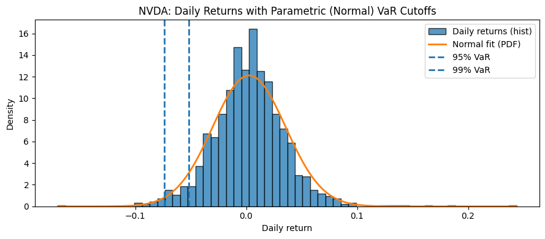

```python
# =========================
# 6) Histogram + Normal overlay + VaR cutoffs (Daily)
# =========================
x = np.linspace(df["simple_rtn"].min(), df["simple_rtn"].max(), 600)
pdf = norm.pdf(x, loc=mu_hat, scale=sigma_hat)

plt.figure(figsize=(9,4))
plt.hist(df["simple_rtn"], bins=60, density=True, edgecolor="black", alpha=0.75, label="Daily returns (hist)")
plt.plot(x, pdf, linewidth=2, label="Normal fit (PDF)")

for c in CONF_LEVELS:
    alpha = 1 - c
    var_r = mu_hat + sigma_hat * norm.ppf(alpha)
    plt.axvline(var_r, linestyle="--", linewidth=2, label=f"{int(c*100)}% VaR")

plt.title(f"{TICKER}: Daily Returns with Parametric (Normal) VaR Cutoffs")
plt.xlabel("Daily return")
plt.ylabel("Density")
plt.legend()
plt.tight_layout()
plt.show()
```

## 7) Visualize Horizon VaR (Optional)

To visualize the parametric horizon distribution, we plot the Normal density for (H)-day returns and the horizon VaR cutoffs.

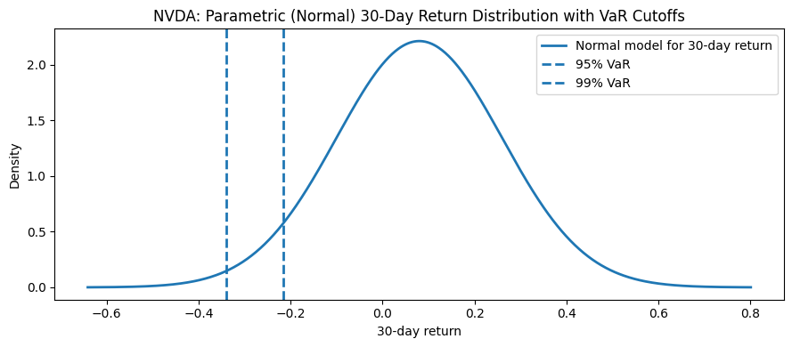

```python
# =========================
# 7) Normal density + VaR cutoffs (Horizon)
# =========================
H = HORIZON_DAYS
mu_H = H * mu_hat
sigma_H = np.sqrt(H) * sigma_hat

xH = np.linspace(mu_H - 4*sigma_H, mu_H + 4*sigma_H, 600)
pdfH = norm.pdf(xH, loc=mu_H, scale=sigma_H)

plt.figure(figsize=(9,4))
plt.plot(xH, pdfH, linewidth=2, label=f"Normal model for {H}-day return")

for c in CONF_LEVELS:
    alpha = 1 - c
    var_h = mu_H + sigma_H * norm.ppf(alpha)
    plt.axvline(var_h, linestyle="--", linewidth=2, label=f"{int(c*100)}% VaR")

plt.title(f"{TICKER}: Parametric (Normal) {H}-Day Return Distribution with VaR Cutoffs")
plt.xlabel(f"{H}-day return")
plt.ylabel("Density")
plt.legend()
plt.tight_layout()
plt.show()
```

## 8) Interpretation prompts (optional)

- Compare Parametric VaR to Historical VaR for the same ticker and confidence level. Which is larger in magnitude?
- If returns are fat‑tailed, what bias might the Normal VaR introduce?
- How does the horizon scaling ((\sqrt{H})) differ conceptually from historical rolling compounding?

## Appendix: Exporting your notebook (for submission)

To export with outputs visible (so the instructor does not need to re-run code):

- **HTML**: File → Save and Export Notebook As → HTML
- **PDF**: File → Save and Export Notebook As → PDF *(may require LaTeX installed)*